# Logbook Janine Postmus

Janine Postmus

2024-10-16

## Introductie

Ons [onderzoek](https://www.ncbi.nlm.nih.gov/geo/query/acc.cgi?acc=GSE153650) kijkt naar de behandeling van entinostat op blaaskanker. Het onderzoek is uitgevoerd op de Muis Musculus, oftewel de huismuis. We gaan kijken naar de rna sequenties, hier halen we de varianten uit en vervolgens kijken we naar de verschillen in varianten tussen de gezonde muis, de zieke muis en een referentiegenoom. In ons plan van aanpak staat beschreven met welke tools we dit gaan doen.

**Sidenote**  
Ik heb afgelopen periode veel pech pech gehad qua lichamelijke gezondheid, ik wil daarom meegeven dat dit logboek lang niet aan mijn eigen standaard voldoet. Ik heb mijn best gedaan om zoveel mogelijk dingen uit te voeren, hier heb ik niet zoveel moeite mee. Echter is de interpretatie van de verschillende plots niet goed, ik heb hier heel veel moeite mee, maar het lukt mij nu niet om me hier voldoende in te verdiepen. Wanneer dit niet aan de beoordelingsstandaarden voldoet, stel ik voor dat ik een verslag mag schrijven over de verschillende plotjes, wanneer je ze gebruikt en waarom je ze gebruikt. Dit zou dan als herkansing gelden.

## Kwaliteitscontrole

We beginnen met de kwaliteitscontrole van de data. Hiervoor gebruiken we de tool FastQC en MultiQC. Deze stap voeren we uit omdat we willen beoordelen of onze data goed genoeg is om mee te werken. Wanneer dit niet het geval is, zullen we met behulp van de tool Trimmomatic, de data dusdanig trimmen dat deze wel goed genoeg is om te gebruiken. Iris heeft deze stap uitgevoerd daarom verwijs ik voor de gebruikte settings en commandlines naar het [logboek van Iris](https://github.com/RamonReilman/GenomicsTranscriptomics/tree/main/Transcriptomics/logbooks)

## STAR (Spliced Transcripts Alignment to a Reference)

Door middel van de tool STAR gaan we de genexpressies kwantificeren. Het referentiegenoom moet worden geindexed door middel van STAR. Ik ga hieronder een command opstellen en deze in samenwerking met Marcel starten. Omdat het een vrij lang proces is starten we dit op vrijdag zodat Ramon zaterdag verder kan met STAR.

De indexing zelf is goed gegaan, echter was er verwarring over de inhoud van het index referentie genoom. Hierop heeft Ramon de indexing opnieuw uitgevoerd en daarna is STAR uitgevoerd door Ramon Reijlman, kijk voor de uitovering van beide stappen in het [logboek van Ramon](https://github.com/RamonReilman/GenomicsTranscriptomics/blob/main/Transcriptomics/logbooks/RamonReilman.Rmd)

## DESeq2 oefening

Door middel van de tool [DESeq2](https://www.bioconductor.org/packages/devel/bioc/vignettes/DESeq2/inst/doc/DESeq2.html) gaan we nu de varianten tegen elkaar aanleggen en voorbereiden voor de statistische verwerking. Omdat we nog nooit met deze tool gewerkt hebben maken we gebruik van testdata om het commando voor deze tool voor te bereiden en uiteindelijk uit te voeren. Ik gebruik hiervoor de volgende [tutorial](https://www.youtube.com/watch?app=desktop&v=OzNzO8qwwp0), inclusief de dataset die hier gebruikt wordt.

Dit script is niet van mij, deze heb ik overgenomen van [github repo](https://github.com/kpatel427/YouTubeTutorials/blob/main/getData.R)

Stap 1 is het voorbereiden van de data zodat er in stap 2 een deseq datast van gemaakt kan worden.

Stap 2 is het maken van de deseq dataset.

Factor level betekend dat we deseq moeten vertellen welke 2 dimensies we gaan vergelijken. Wanneer deze niet gekozen wordt gaat dit op alfabetische volgorde.

Stap 3 is het runnen van de deseq functie. De dingen die meegenomen worden worden uitgelegd in [deze video](https://www.youtube.com/watch?v=0b24mpzM_5M). Hier heb ik mijn informatie vandaan gehaald.

Ik heb de volledige tutorial gevolgd en uitgevoerd. Hierdoor ik weet nu welke parameters ik de tool deseq2 moet meegeven zodat deze gebruikt kan worden.

## Deseq

Factor level betekend dat we deseq moeten vertellen welke 2 dimensies we gaan vergelijken. Wanneer deze niet gekozen wordt gaat dit op alfabetische volgorde.

The design matrix has the same number of samples and coefficients to fit, so estimation of dispersion is not possible. Treating samples as replicates was deprecated in v1.20 and no longer supported since v1.22.  
Dit wijst erop dat het aantal samples en condities niet goed is. Om DESEq2 goed te laten runnen heb ik meer samples dan condities nodig. Hieronder ga ik mijn data controleren op de sample en conditie informatie.

Het probleem bleek te liggen het maken van de deseqdataset. Hierbij moest het design niet [Design = ~ Run] zijn maar [design = ~ 0 + source_name]. Hiermee wordt de goede kolom geselecteerd zodat deseq goed uitgevoerd kan worden.

```r
#Scatter plot
plotMA(res)
```

[output not shown]

## Annot count_data

Het annoteren van onze data zorgt ervoor dat de genen de NCBI naamgeving krijgen. Zo is het straks overzichtelijker om informatie te vinden over de genen.

In de bestanden kon niks gevonden worden over de genen, maar zo is het wel duidelijker waar elke kolom voor staat. Dat moet nu nog toegepast worden in de counts df

Nu zijn de SRR* namen vervangen met waar ze voor staan en is de df duidelijker te lezen, om straks makkelijker de kolommen op te halen die horen bij elk mogelijke variant groepeer ik deze.

Nu kunnen deze variabelen gebruikt worden om de juiste kolommen te selecteren.

Dan kan dit nu samengevoegd worden met mijn code.

## Statistische verwerking

Samen met Jasper ga ik de data visualiseren van de muis met een goed immuunsysteem, hierbij ga ik de baseline tegenover entinostat behandeling toepassen.  
Hiervoor ga ik een nieuwe deseq dataset maken met alleen de gegevens van de C57BL/6 muis met baseline en entinostat.

Om te kijken naar de differential gene analysis zijn we allemaal bezig met visuele weergaven van de data door middel van grafieken en plotjes. Ramon en Iris kijken naar de muis met een slecht immuunsysteem (NSG muis), Jasper en ik kijken naar de muis met een goed immuunsysteem namelijk de C57BL/6 muis. Jasper heeft een vulcano plot gemaakt, hiervoor verwijs ik door naar zijn logboek. Ik ga beginnen met een principale componenten analyse (PCA) en ga daarna een MA plot maken.

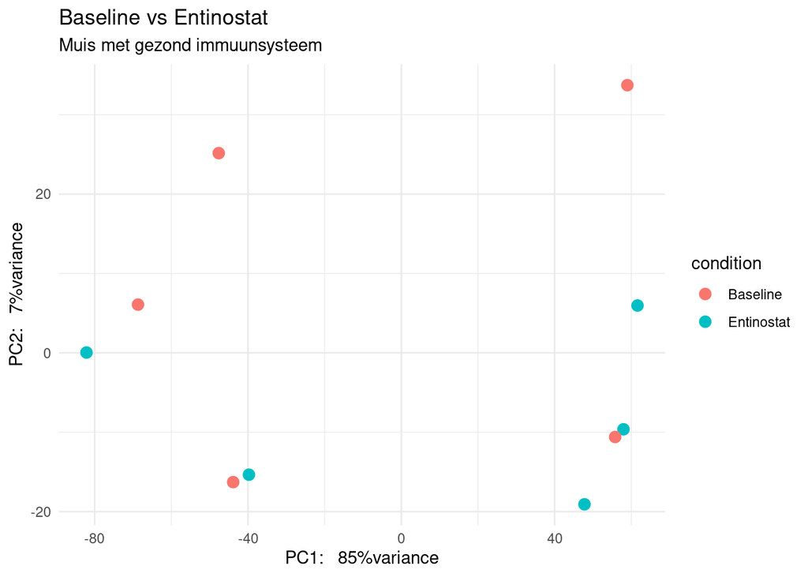

```r
# Eerst variance stabilizing transformation toepassen
vsd <- vst(dds_healthymouse_subset, blind = FALSE, nsub = 1000, fitType = "parametric")

#colData(vsd)

# Daarna de genormaliseerde counts ophalen
normalized_counts <- assay(vsd)


# Vervolgens de PCA berekenen
pcaData <- plotPCA(vsd, intgroup=c("condition"), returnData = TRUE)

# De gegevens van pcaData omzetten naar percentages
percentVar <- round(100 * attr(pcaData, "percentVar"))

# Plotje maken met ggplot2
ggplot(pcaData, aes(PC1, PC2, color = condition)) +
    geom_point(size = 3) +
    xlab(paste0("PC1:   ", percentVar[1], "%variance")) +
    ylab(paste0("PC2:   ", percentVar[2], "%variance")) +
    theme_minimal() +
    labs(title = "Baseline vs Entinostat") +
    labs(subtitle = "Muis met gezond immuunsysteem")
```

Ik ga nu een MA plot maken. Deze toon de log2-fold changes (M-waarden), tegenover de gemiddelde genexpressie (A-waaren). Hierdoor kunnen de genen met significante veranderingen in expressie worden geïdentificeerd.

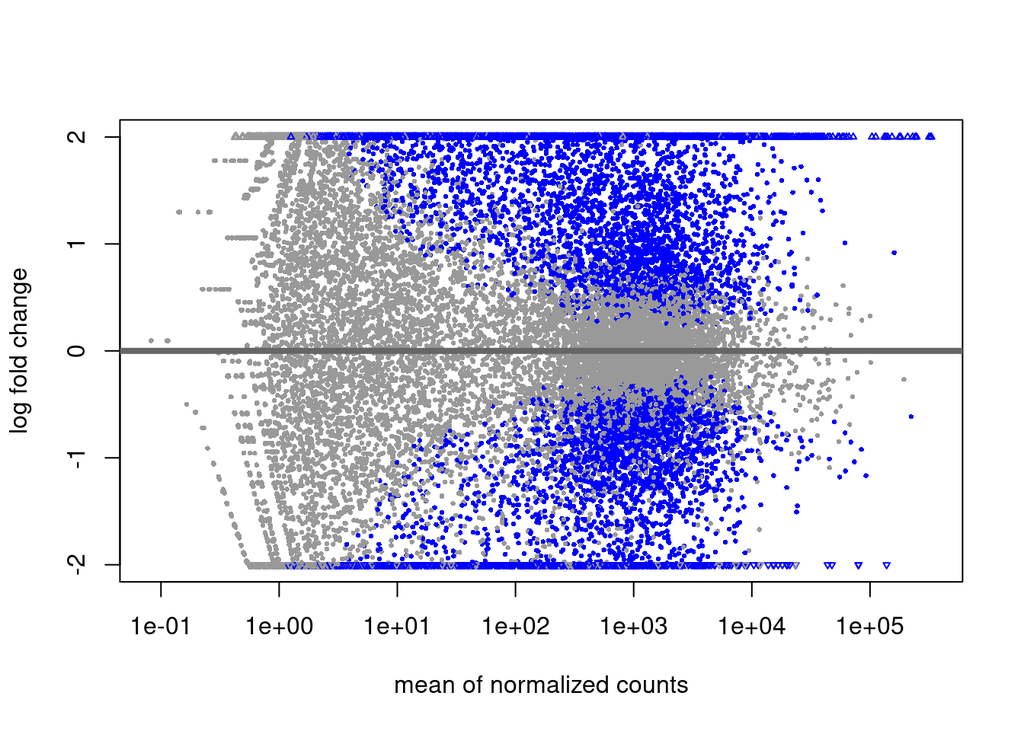

```r
plotMA(mouse_res,
       ylim = c(-2, 2))
```

Ik ga nu een heatmap maken en dit toont de genexpressiesniveaus van verschillende monsters. Het visualiseert patronen van genexpressie en clustering van monsters.

[figure not shown]

```r
heatmap <- pheatmap(assay(vst(dds_healthymouse_subset)), cluster_rows = TRUE, cluster_cols = TRUE)
```

[figure not shown]

```r
#heatmap omzetten naar ggplot object omdat de map onleesbaar is

ggplot_object <- as.ggplot(heatmap)

#plot mooi maken met ggplot2

ggplot_object +
  ggtitle("Heatmap van Genexpressie") +
  theme_minimal() +
  theme(axis.text.x = element_text(angle = 45, hjust = 1),
        plot.title = element_text(hjust = 0.5, size = 14, face = "bold"))
```